# Newton Raphson method

### **NOTES ON STATISTICS, PROBABILITY and MATHEMATICS**

### Newton Raphson Method and Loan Interest:

##### Loan Mathematics:

We take a loan out from the bank: the principal $P$ to be repaid in a fixed amount of time (let’s assume monthly payments $n =360$, corresponding to monthly payments for $30$ years) with interest compounded every month $i = \text{nominal interest}/12$. Every month the payment is $R$ (“rent”) dollars.

At time zero, we take the loan, and it starts accruing interest. After a month, the amount owed will be:

$$P \; (1 +i)$$

at which point we make the first payment. Now the balance will be left at

$$\text{balance owed}= P \; (1 +i) -
R$$

on which interest will be accrued, so that by the end of the second month (and after making the second payment) the balance will be

$$\begin{align}\text{balance owed} &=
\left [P\; (1 + i) - R\; \right] \;(1 + i) - R\\[2ex]
&= P\;(1+i)^2-R(1+i)-R
\end{align}$$

At the end of the third month the balance will be

$$\begin{align}\text{balance owed} &=
\left[P\;(1+i)^2-R\;(1+i)-R\;\right]\;(1+i)-R\\[2ex]
&= P\;(1+i)^3-R\;(1+i)^2-R\;(1+i)-R
\end{align}$$

At the end of the $n$ payments, the balance will be zero

$$\begin{align} 0 &=
P\;(1+i)^n-R\;(1+i)^{n-1}-R\;(1+i)^{n-2}-\;\cdots\;-R\;(1+i)^0\\[2ex]
&=P\;(1+i)^n - R\;\frac{1-(1+i)^n}{1-(1+i)}\\[2ex]
&=P\;(1+i)^n - R\;\frac{(1+i)^n-1}{(1+i)-1}\tag 1\\[2ex]
&=P\;(1+i)^n - R\;\frac{(1+i)^n-1}{i}
\end{align}$$

because $-R\;(1+i)^{n-1}-R\;(1+i)^{n-2}-\;\cdots\;-R\;(1+i)^0$ forms a geometrical series, and

$$\sum_{k=0}^{n-1}a\;r^k=a\;\frac{1-r^n}{1-r}$$

Rearranging,

$$\begin{align}
R\;\frac{(1+i)^n-1}{i}&=P\;(1+i)^n\\[2ex]
R\;\left((1+i)^n-1\right)&=P\;i\;(1+i)^n\\[2ex]
R&=P\;i\;\frac{(1+i)^n}{\left((1+i)^n-1\right)}\tag 2
\end{align}$$

##### NEWTON-RAPHSON METHOD:

We want to find the zro values for Eq $(1)$, and we resort to the Newton-Raphson method, which solves for the $x$ value at which $F(x)=0$ based on a guess that this $x$ value is close to an $a$ value, wuch that

$$F'(a) = \lim_{a\to x}\;
\frac{F(x)-F(a)}{x-a}$$

Assuming that the guess gets better and better, we can get rid of the $\lim$, and express this formula as

$$F'(a) \approx
\frac{F(x)-F(a)}{x-a}$$

Keeping in mind that $F(x)$ is a zero,

$$x\approx a
-\frac{F(a)}{F'(a)}$$

Since $a$ can actually be far from $x$ we update $x$ as

$$x_{i+1} =
x_i-\frac{F(x_i)}{F'(x_i)}$$

Going back to equation $(2),$ and taking into consideration that $i$ is the variable to optimize,

$$F(x) =
\frac{P\;x\;(1+x)^n}{\left((1+x)^n-1\right)}-R$$

Therefore,

$$\begin{align}
F'(x)&=\frac{\partial \left(\frac{P x
(x+1)^n}{(x+1)^n-1}-R\right)}{\partial x}\\[2ex]
&=\frac{n P x (x+1)^{n-1}}{(x+1)^n-1}+\frac{P
(x+1)^n}{(x+1)^n-1}-\frac{n
P x (x+1)^{2 n-1}}{\left((x+1)^n-1\right)^2}\\[2ex]
&=\frac{P (x+1)^{n-1} \left(x (x+1)^n+(x+1)^n-n
x-x-1\right)}{\left((x+1)^n-1\right)^2}
\end{align}$$

Let’s now give some values to the principal and the payment… Say we bought a new phone because we were eligible after a couple of years of using a the iFone 3.0. The new phone is the iFone 3.1, and costs $P= \$ 700$. The salesman at AT&T tells you that you’ll pay $R =\$ 35$ for $n=24$ months. What is the interest rate being charged?

$$F(x) =
\frac{700\;x\;(1+x)^{24}}{\left((1+x)^{24}-1\right)}-35$$

$$F'(x)=\frac{16800\, x
(x+1)^{23}}{(x+1)^{24}-1}+\frac{P
(x+1)^{24}}{(x+1)^{24}-1}-\frac{16800\, x
(x+1)^{47}}{\left((x+1)^{24}-1\right)^2}$$

Plotting $F(x),$

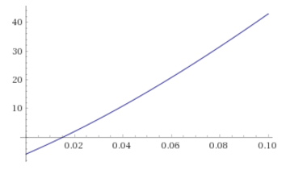

would allow us to start the guessing game at $0.02$, which corresponds to a nominal annual interest of $0.02 \times 12=24\%.$ Otherwise we could just pretend that there is no compounding and guess $\frac{R\times n}{P}=\frac{35\times 24}{700}= 1.2\implies i = 0.2/12= 0.016.$

In [this post](https://blog.bossylobster.com/2012/05/reverse-calculating-interest-rate) there is a nice simplification that helps get a cleaner code expression, and a simpler derivative: instead of working with $i=x,$ we set up $x=1+\frac{i}{12},$ in which case, and going back to equation $(1),$

$$\begin{align}
&P\;(1+i)^n = R\;\frac{(1+i)^n-1}{(1+i)-1}\\[2ex]
&P\,x^n\,(x-1)=R\,(x^n-1)\\[2ex]
&F(x)=P\,x^n\,(x-1)-R\,(x^n-1)\\[2ex]
&F(x)=P\,x^{n+1}\,-(P+R)\,x^n+R
\end{align}$$

a nice polynomial, which derivative is

$$F'(x)=P\, (n+1)\,
x^n-(P+R)\,n\,x^{n-1}$$

And the R code,

```r
interest = function(loan, pmt, n){
  F =       function(x) (loan * x^(n+1) - (loan + pmt) * x^n + pmt)
  F_prime = function(x) (loan * (n+1) * x^n - (loan + pmt) * n * x^(n-1))

  guess = 1 + (((pmt * n / loan) - 1) / 12)

  x = guess

    while(abs(F(x)) > (1e-6)){
      x = x -  F(x)/ F_prime(x)
      print(x)
    }
  paste("Yearly interest: ", round((12 * (x - 1) * 100),3)," percent")
}

interest(700,35,24)
```

```
## [1] 1.01529
## [1] 1.015133
## [1] 1.015131
```

```
## [1] "Yearly interest:  18.157  percent"
```

Double-checking with a financial calculator:

```
700   PV
0     FV
-35   PMT
24    n
i
g     12x
```

Of course, this should also work out using the more convoluted formulas:

```r
interest = function(loan, pmt, n){
  F =       function(x) (loan * x * (1 + x)^n)/((1+x)^n - 1) - pmt
  F_prime = function(x) (loan * (x+1)^(n-1) * (x*(x+1)^n + (x+1)^n-n*x-x-1)) / ((x+1)^n - 1)^2

  guess = 1 + (((pmt * n / loan) - 1) / 12)

  x = guess

    while(abs(F(x)) > (1e-6)){
      x = x -  F(x)/ F_prime(x)
      print(x)
    }
  paste("Yearly interest: ", round((12 * x * 100),3)," percent")
}

interest(700,35,24)
```

```
## [1] 0.04999943
## [1] 0.01812481
## [1] 0.01515984
## [1] 0.01513085
## [1] 0.01513084
```

```
## [1] "Yearly interest:  18.157  percent"
```

[Home Page](http://rinterested.github.io/statistics/index.html)

**NOTE: These are tentative notes on different topics for personal use - expect mistakes and misunderstandings.**